# Mexico City’s Underground

- Show All Code
- Hide All Code

A History of Challenges and Triumphs

python

Author

Jesus L. Monroy

Published

Sep, 2024

Abstract

Mexico City’s metro is the largest and busiest in Latin America, serving more than 5.5 million passengers daily in its 195 stations and 12 lines

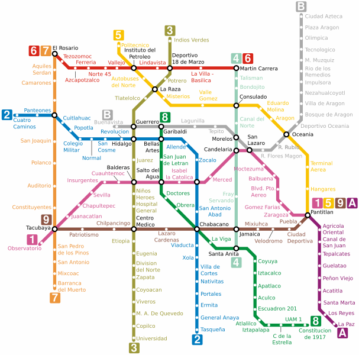

Figure 1: Mexico City’s Subway Network

# Mexico City’s Metro

Mexico City’s subway system, named “Sistema de Transporte Colectivo” (STC), is a vital artery of the bustling metropolis, transporting millions of commuters daily. Its history is a tale of innovation, resilience, and the constant struggle to meet the demands of a rapidly growing city.

## Challenges and Overcoming Adversity

Despite its success, the STC has faced numerous challenges throughout its history. One of the most significant issues has been overcrowding, particularly during peak hours. The system’s capacity has often been strained, leading to long wait times and uncomfortable conditions for commuters. To address this problem, the authorities have implemented various measures, including expanding the network and improving train frequency.

Another challenge has been the maintenance and upkeep of the system. The STC’s infrastructure is aging, and some sections require significant repairs and upgrades. Ensuring the safety and reliability of the system has been a constant priority for the authorities. In recent years, there have been efforts to modernize the infrastructure and improve maintenance practices.

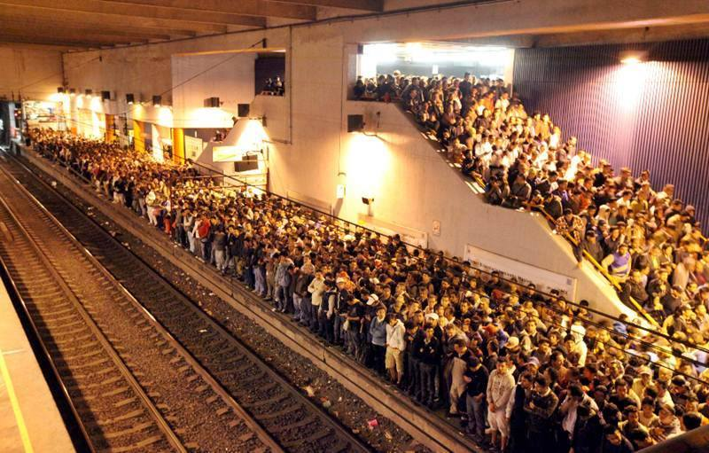

Figure 2: Inside the Subway

## The Future of the STC

Looking ahead, the STC faces both opportunities and challenges. The government has ambitious plans to further expand the system, connecting new areas of the city and improving accessibility. However, these projects require substantial investment and careful planning. Additionally, the STC will need to adapt to changing demographics and transportation trends, such as the rise of electric vehicles and ride-sharing services.

Despite the challenges, the STC remains a vital component of Mexico City’s urban landscape. Its history is a testament to the city’s resilience and its ability to adapt to changing circumstances. As Mexico City continues to grow and evolve, the STC will play a crucial role in shaping its future.

### Creating Beautiful Tables with Python and Great-Tables

```python
# import libraries
import polars as pl
import duckdb as db
from great_tables import GT, md, html, loc, style
```

```python
# connect to dabase
conn = db.connect('my_database.db')
```

```python
# retrieve data from table to dataframe
df = conn.sql('select * from cdmx_subway').pl()
```

```python
# close connection
conn.close()
```

```python
# Change datatypes
df = df.select(pl.exclude('Line'))
```

```python
# Create table with great-tables
cdmx = (
    GT(df)
    .tab_header(
        title=md("### Mexico City's Subway Lines and Stations"),
        subtitle=html('''<h4 align="left">
        Mexico City's metro system is a vital artery of the bustling metropolis.
        It is the largest and busiest in Latin America, serving more than 5.5 million
        passengers daily in its 195 stations and 12 lines.</h4>''')
    )
    #.tab_options(table_width="100%")
    .cols_align(align='center', columns=['icon','Opening date','Stations'])
    .cols_label(
        icon="Line Sation"
    )
    .fmt_date(columns='Opening date', date_style="m_day_year")
    .fmt_image("icon", path="cdmx_metro_lines")
    .sub_missing(missing_text="")
    .tab_source_note(source_note=md('''**Jesus L. Monroy**<br>*Economist & Data Scientist*<br><br>'''))
    .tab_source_note(
        source_note=md('''Source: [Wikipedia](https://en.wikipedia.org/wiki/Mexico_City_Metro>Wikipedia)'''))
)
```

Mexico City's Subway Lines and Stations

Mexico City's metro system is a vital artery of the bustling metropolis. It is the largest and busiest in Latin America, serving more than 5.5 million passengers daily in its 195 stations and 12 lines.

Line Sation

Opening date

Stations

Aug 22, 1984

20

Aug 22, 1984

24

Dec 1, 1979

21

Aug 29, 1981

10

Dec 19, 1981

13

Dec 21, 1983

11

Nov 29, 1988

14

Jul 20, 1994

19

Aug 26, 1987

12

Oct 30, 2012

20

Aug 12, 1991

10

Dec 15, 1999

21

**Jesus L. Monroy**  
*Economist & Data Scientist*

Source: Wikipedia

## Contact

**Jesus L. Monroy**  
*Economist & Data Scientist*

[Medium](https://medium.com/@jesuslm) | [Linkedin](https://www.linkedin.com/in/j3sus-lm) | [Twitter](https://x.com/j3suslm)